# Trabajo Práctico N°2

Esmeralda Provitina

### Introducción

El objetivo del presente trabajo es poder integrar todos los conceptos vistos durante el curso, pero principalmente los del módulo #2.

### Sobre mí

¡Hola! Soy Esmeralda, una estudiante que se está adentrando en el mundo de la ciencia de datos. Este es mi trabajo para el curso de R de la UTN. Elegí trabajar con el dataset “smoking prediction” porque me pareció interesante explorar cómo el -mal- hábito de fumar impacta en las distintas variables del cuerpo y en la salud bucal. Además, fue recomendado por mi docente como buena base para los principiantes.

# Cargamos las librerías necesarias

```r
library(dplyr)
library(ggplot2)
```

# Data Wrangling

Antes de comenzar con el análisis, es fundamental realizar la limpieza íntegra de los datos. Tal como vimos en clase, importaremos el Dataset y lo “limpiaremos”.

```r
DF <- read.csv("7_smoking_prediction.csv", header = TRUE, sep = ",", stringsAsFactors = TRUE)

###Ver nombres de variables
names(DF)
```

```
 [1] "ID"                  "gender"              "age"
 [4] "height.cm."          "weight.kg."          "waist.cm."
 [7] "eyesight.left."      "eyesight.right."     "hearing.left."
[10] "hearing.right."      "systolic"            "relaxation"
[13] "fasting.blood.sugar" "Cholesterol"         "triglyceride"
[16] "HDL"                 "LDL"                 "hemoglobin"
[19] "Urine.protein"       "serum.creatinine"    "AST"
[22] "ALT"                 "Gtp"                 "oral"
[25] "dental.caries"       "tartar"              "smoking"
```

```r
###Eliminación de casos incompletos (Missing values)
DF <- DF[complete.cases(DF),]
### Verificación de datos faltantes
anyNA(DF)
```

```
[1] FALSE
```

```r
### Identificación de valores faltantes
is.na(DF)
```

[output not shown]

[output cut: 214 more lines]

```r
### Verificación de valores numéricos inválidos
sapply (DF, is.infinite)
```

[output not shown]

[output cut: 214 more lines]

```r
sapply(DF, is.nan)
```

[output not shown]

[output cut: 214 more lines]

```r
###Eliminación de variable irrelevante
DF$ID <- NULL
```

# Análisis exploratorio

Se realiza un análisis exploratorio con el objetivo de comprender la estructura del DS, identificar los tipos de variables y analizar su distribución.

```r
# Estructura del dataset
str(DF)
```

```
'data.frame':   55692 obs. of  26 variables:
 $ gender             : Factor w/ 2 levels "F","M": 1 1 2 2 1 2 2 2 1 2 ...
 $ age                : int  40 40 55 40 40 30 40 45 50 45 ...
 $ height.cm.         : int  155 160 170 165 155 180 160 165 150 175 ...
 $ weight.kg.         : int  60 60 60 70 60 75 60 90 60 75 ...
 $ waist.cm.          : num  81.3 81 80 88 86 85 85.5 96 85 89 ...
 $ eyesight.left.     : num  1.2 0.8 0.8 1.5 1 1.2 1 1.2 0.7 1 ...
 $ eyesight.right.    : num  1 0.6 0.8 1.5 1 1.2 1 1 0.8 1 ...
 $ hearing.left.      : num  1 1 1 1 1 1 1 1 1 1 ...
 $ hearing.right.     : num  1 1 1 1 1 1 1 1 1 1 ...
 $ systolic           : num  114 119 138 100 120 128 116 153 115 113 ...
 $ relaxation         : num  73 70 86 60 74 76 82 96 74 64 ...
 $ fasting.blood.sugar: num  94 130 89 96 80 95 94 158 86 94 ...
 $ Cholesterol        : num  215 192 242 322 184 217 226 222 210 198 ...
 $ triglyceride       : num  82 115 182 254 74 199 68 269 66 147 ...
 $ HDL                : num  73 42 55 45 62 48 55 34 48 43 ...
 $ LDL                : num  126 127 151 226 107 129 157 134 149 126 ...
 $ hemoglobin         : num  12.9 12.7 15.8 14.7 12.5 16.2 17 15 13.7 16 ...
 $ Urine.protein      : num  1 1 1 1 1 1 1 1 1 1 ...
 $ serum.creatinine   : num  0.7 0.6 1 1 0.6 1.2 0.7 1.3 0.8 0.8 ...
 $ AST                : num  18 22 21 19 16 18 21 38 31 26 ...
 $ ALT                : num  19 19 16 26 14 27 27 71 31 24 ...
 $ Gtp                : num  27 18 22 18 22 33 39 111 14 63 ...
 $ oral               : Factor w/ 1 level "Y": 1 1 1 1 1 1 1 1 1 1 ...
 $ dental.caries      : int  0 0 0 0 0 0 1 0 0 0 ...
 $ tartar             : Factor w/ 2 levels "N","Y": 2 2 1 2 1 2 2 2 1 1 ...
 $ smoking            : int  0 0 1 0 0 0 1 0 0 0 ...
```

```r
#Resumen general de las variables
summary(DF)
```

```
 gender         age          height.cm.      weight.kg.
 F:20291   Min.   :20.00   Min.   :130.0   Min.   : 30.00
 M:35401   1st Qu.:40.00   1st Qu.:160.0   1st Qu.: 55.00
           Median :40.00   Median :165.0   Median : 65.00
           Mean   :44.18   Mean   :164.6   Mean   : 65.86
           3rd Qu.:55.00   3rd Qu.:170.0   3rd Qu.: 75.00
           Max.   :85.00   Max.   :190.0   Max.   :135.00
   waist.cm.      eyesight.left.  eyesight.right. hearing.left.
 Min.   : 51.00   Min.   :0.100   Min.   :0.100   Min.   :1.000
 1st Qu.: 76.00   1st Qu.:0.800   1st Qu.:0.800   1st Qu.:1.000
 Median : 82.00   Median :1.000   Median :1.000   Median :1.000
 Mean   : 82.05   Mean   :1.013   Mean   :1.007   Mean   :1.026
 3rd Qu.: 88.00   3rd Qu.:1.200   3rd Qu.:1.200   3rd Qu.:1.000
 Max.   :129.00   Max.   :9.900   Max.   :9.900   Max.   :2.000
 hearing.right.     systolic       relaxation  fasting.blood.sugar
 Min.   :1.000   Min.   : 71.0   Min.   : 40   Min.   : 46.00
 1st Qu.:1.000   1st Qu.:112.0   1st Qu.: 70   1st Qu.: 89.00
 Median :1.000   Median :120.0   Median : 76   Median : 96.00
 Mean   :1.026   Mean   :121.5   Mean   : 76   Mean   : 99.31
 3rd Qu.:1.000   3rd Qu.:130.0   3rd Qu.: 82   3rd Qu.:104.00
 Max.   :2.000   Max.   :240.0   Max.   :146   Max.   :505.00
  Cholesterol     triglyceride        HDL              LDL
 Min.   : 55.0   Min.   :  8.0   Min.   :  4.00   Min.   :   1
 1st Qu.:172.0   1st Qu.: 74.0   1st Qu.: 47.00   1st Qu.:  92
 Median :195.0   Median :108.0   Median : 55.00   Median : 113
 Mean   :196.9   Mean   :126.7   Mean   : 57.29   Mean   : 115
 3rd Qu.:220.0   3rd Qu.:160.0   3rd Qu.: 66.00   3rd Qu.: 136
 Max.   :445.0   Max.   :999.0   Max.   :618.00   Max.   :1860
   hemoglobin    Urine.protein   serum.creatinine       AST
 Min.   : 4.90   Min.   :1.000   Min.   : 0.1000   Min.   :   6.00
 1st Qu.:13.60   1st Qu.:1.000   1st Qu.: 0.8000   1st Qu.:  19.00
 Median :14.80   Median :1.000   Median : 0.9000   Median :  23.00
 Mean   :14.62   Mean   :1.087   Mean   : 0.8857   Mean   :  26.18
 3rd Qu.:15.80   3rd Qu.:1.000   3rd Qu.: 1.0000   3rd Qu.:  28.00
 Max.   :21.10   Max.   :6.000   Max.   :11.6000   Max.   :1311.00
      ALT               Gtp         oral      dental.caries
 Min.   :   1.00   Min.   :  1.00   Y:55692   Min.   :0.0000
 1st Qu.:  15.00   1st Qu.: 17.00             1st Qu.:0.0000
 Median :  21.00   Median : 25.00             Median :0.0000
 Mean   :  27.04   Mean   : 39.95             Mean   :0.2133
 3rd Qu.:  31.00   3rd Qu.: 43.00             3rd Qu.:0.0000
 Max.   :2914.00   Max.   :999.00             Max.   :1.0000
 tartar       smoking
 N:24752   Min.   :0.0000
 Y:30940   1st Qu.:0.0000
           Median :0.0000
           Mean   :0.3673
           3rd Qu.:1.0000
           Max.   :1.0000
```

```r
#Separación de las variables en numéricas y cuali para analizarlas de manera más específica
class(DF)
```

```
[1] "data.frame"
```

```r
numericas <- DF[sapply(DF,is.numeric)]
summary(numericas)
```

```
      age          height.cm.      weight.kg.       waist.cm.
 Min.   :20.00   Min.   :130.0   Min.   : 30.00   Min.   : 51.00
 1st Qu.:40.00   1st Qu.:160.0   1st Qu.: 55.00   1st Qu.: 76.00
 Median :40.00   Median :165.0   Median : 65.00   Median : 82.00
 Mean   :44.18   Mean   :164.6   Mean   : 65.86   Mean   : 82.05
 3rd Qu.:55.00   3rd Qu.:170.0   3rd Qu.: 75.00   3rd Qu.: 88.00
 Max.   :85.00   Max.   :190.0   Max.   :135.00   Max.   :129.00
 eyesight.left.  eyesight.right. hearing.left.   hearing.right.
 Min.   :0.100   Min.   :0.100   Min.   :1.000   Min.   :1.000
 1st Qu.:0.800   1st Qu.:0.800   1st Qu.:1.000   1st Qu.:1.000
 Median :1.000   Median :1.000   Median :1.000   Median :1.000
 Mean   :1.013   Mean   :1.007   Mean   :1.026   Mean   :1.026
 3rd Qu.:1.200   3rd Qu.:1.200   3rd Qu.:1.000   3rd Qu.:1.000
 Max.   :9.900   Max.   :9.900   Max.   :2.000   Max.   :2.000
    systolic       relaxation  fasting.blood.sugar  Cholesterol
 Min.   : 71.0   Min.   : 40   Min.   : 46.00      Min.   : 55.0
 1st Qu.:112.0   1st Qu.: 70   1st Qu.: 89.00      1st Qu.:172.0
 Median :120.0   Median : 76   Median : 96.00      Median :195.0
 Mean   :121.5   Mean   : 76   Mean   : 99.31      Mean   :196.9
 3rd Qu.:130.0   3rd Qu.: 82   3rd Qu.:104.00      3rd Qu.:220.0
 Max.   :240.0   Max.   :146   Max.   :505.00      Max.   :445.0
  triglyceride        HDL              LDL         hemoglobin
 Min.   :  8.0   Min.   :  4.00   Min.   :   1   Min.   : 4.90
 1st Qu.: 74.0   1st Qu.: 47.00   1st Qu.:  92   1st Qu.:13.60
 Median :108.0   Median : 55.00   Median : 113   Median :14.80
 Mean   :126.7   Mean   : 57.29   Mean   : 115   Mean   :14.62
 3rd Qu.:160.0   3rd Qu.: 66.00   3rd Qu.: 136   3rd Qu.:15.80
 Max.   :999.0   Max.   :618.00   Max.   :1860   Max.   :21.10
 Urine.protein   serum.creatinine       AST
 Min.   :1.000   Min.   : 0.1000   Min.   :   6.00
 1st Qu.:1.000   1st Qu.: 0.8000   1st Qu.:  19.00
 Median :1.000   Median : 0.9000   Median :  23.00
 Mean   :1.087   Mean   : 0.8857   Mean   :  26.18
 3rd Qu.:1.000   3rd Qu.: 1.0000   3rd Qu.:  28.00
 Max.   :6.000   Max.   :11.6000   Max.   :1311.00
      ALT               Gtp         dental.caries       smoking
 Min.   :   1.00   Min.   :  1.00   Min.   :0.0000   Min.   :0.0000
 1st Qu.:  15.00   1st Qu.: 17.00   1st Qu.:0.0000   1st Qu.:0.0000
 Median :  21.00   Median : 25.00   Median :0.0000   Median :0.0000
 Mean   :  27.04   Mean   : 39.95   Mean   :0.2133   Mean   :0.3673
 3rd Qu.:  31.00   3rd Qu.: 43.00   3rd Qu.:0.0000   3rd Qu.:1.0000
 Max.   :2914.00   Max.   :999.00   Max.   :1.0000   Max.   :1.0000
```

```r
cualitativas <- DF[!sapply(DF,is.numeric)]
#Distribución de variables categóricas
summary(cualitativas)
```

```
 gender    oral      tartar
 F:20291   Y:55692   N:24752
 M:35401             Y:30940
```

```r
#Medidas de tendencia central, dispersión y relaciones entre variables
sapply(numericas, IQR)
```

```
                age          height.cm.          weight.kg.
               15.0                10.0                20.0
          waist.cm.      eyesight.left.     eyesight.right.
               12.0                 0.4                 0.4
      hearing.left.      hearing.right.            systolic
                0.0                 0.0                18.0
         relaxation fasting.blood.sugar         Cholesterol
               12.0                15.0                48.0
       triglyceride                 HDL                 LDL
               86.0                19.0                44.0
         hemoglobin       Urine.protein    serum.creatinine
                2.2                 0.0                 0.2
                AST                 ALT                 Gtp
                9.0                16.0                26.0
      dental.caries             smoking
                0.0                 1.0
```

```r
sapply(numericas, range)
```

```
     age height.cm. weight.kg. waist.cm. eyesight.left.
[1,]  20        130         30        51            0.1
[2,]  85        190        135       129            9.9
     eyesight.right. hearing.left. hearing.right. systolic relaxation
[1,]             0.1             1              1       71         40
[2,]             9.9             2              2      240        146
     fasting.blood.sugar Cholesterol triglyceride HDL  LDL hemoglobin
[1,]                  46          55            8   4    1        4.9
[2,]                 505         445          999 618 1860       21.1
     Urine.protein serum.creatinine  AST  ALT Gtp dental.caries
[1,]             1              0.1    6    1   1             0
[2,]             6             11.6 1311 2914 999             1
     smoking
[1,]       0
[2,]       1
```

```r
sapply(numericas, quantile)
```

```
     age height.cm. weight.kg. waist.cm. eyesight.left.
0%    20        130         30        51            0.1
25%   40        160         55        76            0.8
50%   40        165         65        82            1.0
75%   55        170         75        88            1.2
100%  85        190        135       129            9.9
     eyesight.right. hearing.left. hearing.right. systolic relaxation
0%               0.1             1              1       71         40
25%              0.8             1              1      112         70
50%              1.0             1              1      120         76
75%              1.2             1              1      130         82
100%             9.9             2              2      240        146
     fasting.blood.sugar Cholesterol triglyceride HDL  LDL hemoglobin
0%                    46          55            8   4    1        4.9
25%                   89         172           74  47   92       13.6
50%                   96         195          108  55  113       14.8
75%                  104         220          160  66  136       15.8
100%                 505         445          999 618 1860       21.1
     Urine.protein serum.creatinine  AST  ALT Gtp dental.caries
0%               1              0.1    6    1   1             0
25%              1              0.8   19   15  17             0
50%              1              0.9   23   21  25             0
75%              1              1.0   28   31  43             0
100%             6             11.6 1311 2914 999             1
     smoking
0%         0
25%        0
50%        0
75%        1
100%       1
```

```r
cor(numericas)
```

```
                             age   height.cm.  weight.kg.   waist.cm.
age                  1.000000000 -0.479528389 -0.32470578 -0.02629698
height.cm.          -0.479528389  1.000000000  0.67565614  0.37890172
weight.kg.          -0.324705779  0.675656139  1.00000000  0.82284205
waist.cm.           -0.026296979  0.378901721  0.82284205  1.00000000
eyesight.left.      -0.195472478  0.151133335  0.10843283  0.02745763
eyesight.right.     -0.192722740  0.155665003  0.11315489  0.03799640
hearing.left.        0.203993022 -0.078663324 -0.05009438  0.02378961
hearing.right.       0.208722307 -0.078322537 -0.05283605  0.01928588
systolic             0.134022882  0.080585041  0.26613094  0.31692169
relaxation           0.050745453  0.113193381  0.27163438  0.29262725
fasting.blood.sugar  0.182351142  0.019618673  0.13623668  0.21113247
Cholesterol          0.055557113 -0.082161134  0.02640309  0.06546703
triglyceride         0.015102443  0.156692718  0.32442884  0.36192184
HDL                  0.007047168 -0.213284273 -0.35886796 -0.37620325
LDL                  0.043006877 -0.048419371  0.04056004  0.07281686
hemoglobin          -0.263078379  0.539367298  0.49296996  0.38706590
Urine.protein        0.029624795  0.005128465  0.03256584  0.04549177
serum.creatinine    -0.106118031  0.383883178  0.32480776  0.23502434
AST                  0.032575836  0.041737379  0.12013017  0.14268958
ALT                 -0.063936864  0.126510909  0.25063431  0.25247771
Gtp                  0.013031374  0.139720379  0.20962461  0.24314127
dental.caries       -0.114984070  0.079331077  0.07353627  0.04420286
smoking             -0.162556772  0.396675270  0.30277996  0.22625929
                    eyesight.left. eyesight.right. hearing.left.
age                   -0.195472478    -0.192722740   0.203993022
height.cm.             0.151133335     0.155665003  -0.078663324
weight.kg.             0.108432830     0.113154888  -0.050094378
waist.cm.              0.027457632     0.037996404   0.023789613
eyesight.left.         1.000000000     0.354574443  -0.046570526
eyesight.right.        0.354574443     1.000000000  -0.043877207
hearing.left.         -0.046570526    -0.043877207   1.000000000
hearing.right.        -0.048787509    -0.046622725   0.510095326
systolic              -0.019329842    -0.013719840   0.055218706
relaxation             0.005199134     0.011357136   0.008754072
fasting.blood.sugar   -0.041850660    -0.044006003   0.042313843
Cholesterol           -0.004985069    -0.007851221  -0.023275966
triglyceride           0.019716761     0.019880543   0.004749972
HDL                   -0.015296089    -0.022220117  -0.020158516
LDL                   -0.007256690    -0.006171916  -0.016706024
```

[output cut: 137 more lines]

```
systolic             0.07310940
relaxation           0.10830938
fasting.blood.sugar  0.10027858
Cholesterol         -0.02854785
triglyceride         0.25179905
HDL                 -0.17847022
LDL                 -0.04522028
hemoglobin           0.40067759
Urine.protein        0.01426719
serum.creatinine     0.21681219
AST                  0.05925321
ALT                  0.09733797
Gtp                  0.23661892
dental.caries        0.10385740
smoking              1.00000000
```

```r
sapply(numericas, mean)
```

```
                age          height.cm.          weight.kg.
         44.1829168         164.6493213          65.8649357
          waist.cm.      eyesight.left.     eyesight.right.
         82.0464178           1.0126230           1.0074427
      hearing.left.      hearing.right.            systolic
          1.0255872           1.0261438         121.4942182
         relaxation fasting.blood.sugar         Cholesterol
         76.0048301          99.3123249         196.9014221
       triglyceride                 HDL                 LDL
        126.6656970          57.2903469         114.9645012
         hemoglobin       Urine.protein    serum.creatinine
         14.6225921           1.0872118           0.8857376
                AST                 ALT                 Gtp
         26.1829347          27.0360375          39.9522014
      dental.caries             smoking
          0.2133341           0.3672879
```

```r
sapply(numericas,median)
```

```
                age          height.cm.          weight.kg.
               40.0               165.0                65.0
          waist.cm.      eyesight.left.     eyesight.right.
               82.0                 1.0                 1.0
      hearing.left.      hearing.right.            systolic
                1.0                 1.0               120.0
         relaxation fasting.blood.sugar         Cholesterol
               76.0                96.0               195.0
       triglyceride                 HDL                 LDL
              108.0                55.0               113.0
         hemoglobin       Urine.protein    serum.creatinine
               14.8                 1.0                 0.9
                AST                 ALT                 Gtp
               23.0                21.0                25.0
      dental.caries             smoking
                0.0                 0.0
```

# Planteo de preguntas: a partir del dataset, formulé los siguientes interrogantes para guiar el análisis:

1. ¿Cuál es el porcentaje de fumadores y no fumadores?
2. ¿La proporción de fumadores cambia según el género? ¿Cómo se distribuye?
3. ¿Cuál es la edad promedio de los fumadores en comparación de los que no fuman?
4. ¿Cuál es el nivel promedio de glucosa (azúcar en sangre en ayunas) en fumadores y en los no fumadores?
5. ¿Existe relación entre la edad y el IMC aquí?
6. ¿Hay diferencia entre en la presión arterial entre fumadores y no fumadores?
7. ¿Existen diferencias en los niveles de grasas en sangre entre los que fuman y los que no?
8. ¿Los fumadores tienen los niveles de hemoglobina más altos?
9. ¿Los fumadores tienen peor salud bucal, teniendo en cuenta los indicadores de sarro y caries?
10. ¿Hay diferencias en la distribución del IMC entre fumadores y no fumadores?

# Respuestas a los interrogantes

Para responder a las preguntas planteadas, se construyen tablas de contingencia y visualizaciones que permiten analizar la distribución de fumadores y no fumadores según distintas variables.

```r
# Conversión a factores para mejor interpretación
DF$smoking_f <- factor(DF$smoking, levels = c(0, 1), labels = c("No fumador", "Fumador"))
DF$gender_f <- factor(DF$gender)

#Tabla de contingencia

tabla_fuma_gen <- table(DF$gender_f, DF$smoking_f)
tabla_fuma_gen
```

```
    No fumador Fumador
  F      19432     859
  M      15805   19596
```

```r
(round(prop.table(tabla_fuma_gen, margin = 1) * 100, 2))
```

```
    No fumador Fumador
  F      95.77    4.23
  M      44.65   55.35
```

```r
# Resumen usando dplyr y pipes
resumen_fum <- DF %>%
  group_by(gender_f, smoking_f) %>%
  summarise(cantidad = n (), .groups = 'drop') %>%
  group_by(gender_f) %>%
  mutate(porcentaje = cantidad / sum(cantidad) * 100)

resumen_fum
```

| gender_f | smoking_f | cantidad | porcentaje |
| --- | --- | --- | --- |
| F | No fumador | 19432 | 95.766596 |
| F | Fumador | 859 | 4.233404 |
| M | No fumador | 15805 | 44.645631 |
| M | Fumador | 19596 | 55.354369 |

```r
# Gráfico n°1: proporción de fumadores según género

gr1 <- ggplot(resumen_fum, aes(x = gender_f, y = cantidad, fill = smoking_f)) +
  geom_bar(stat = "identity", position = "fill") +
  geom_text(aes(label = paste0(round(porcentaje, 1), "%")),
            position = position_fill(vjust = 0.5),
            color = "white") +
            labs(title = "1. Proporción de fumadores según género",
                 subtitle = "Distribución porcentual por género",
                 x = "Género", y = "Proporción", fill = "Estado") +
              theme_minimal()
```

```r
# Gráfico n°2: Distribución por grupos

gr2 <- ggplot(DF, aes(x = gender_f, fill = smoking_f)) +
  geom_bar(position = "dodge") +
  coord_flip() +
  labs(title = "2. Distribución agrupada de fumadores por género horizontal",
       x = "Género", y = "Cantidad absoluta", fill = "Estado") +
  theme_bw()
```

Resultados: se observa que la cantidad de hombres es significativamente mayor que la de mujeres fumadoras. Las mujeres presentan, contrariamente, una mayor cantidad de no fumadoras, reforzando el gráfico anterior.

```r
# Gráfico n° 3: Distribución por facetas

gr3 <- ggplot(DF, aes(x = smoking_f, fill = gender_f)) +
  geom_bar() +
  facet_wrap(~ gender_f) +
  labs (title = "3. Distribución separada por facetas",
        x= "Estado", y = "Cantidad absoluta") +
  theme_light() +
  theme(legend.position = "none")
```

Resultado: en las mujeres predominan las no fumadoras.

```r
# Gráfico n° 4: Frecuencia de combinaciones

gr4 <- ggplot(DF, aes(x = gender_f, y = smoking_f)) +
  geom_count(color = "steelblue") +
  labs(title = "4. Frecuencia de combinaciones",
       x = "Género", y = "Estado", size = "N° de casos") +
  theme_classic()
```

Resultado: la burbuja más grande está en los hombres fumadores comparativamente con las mujeres.

```r
# Gráfico n° 5: Comparando porcentajes

gr5 <- ggplot(resumen_fum, aes(x = smoking_f, y = porcentaje, fill = gender_f)) +
                            geom_bar(stat = "identity", position = "dodge")+
                                 labs(title = "5. Comparativa de porcentajes",
                                      x ="Estado", y = "Porcentaje (%)", fill = "Género") +
                                 theme_minimal()
```

Resultado: el hábito de fumar está fuertemente asociado al género en este dataset.

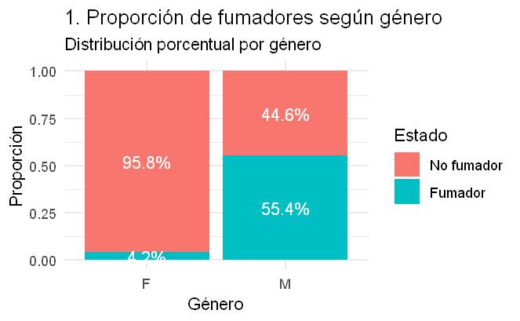

```r
gr1
```

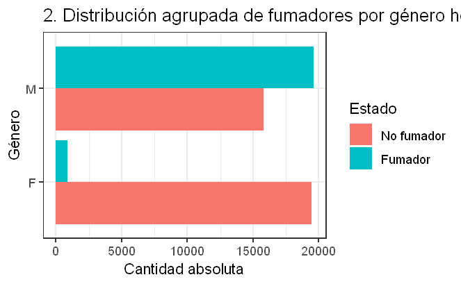

```r
gr2
```

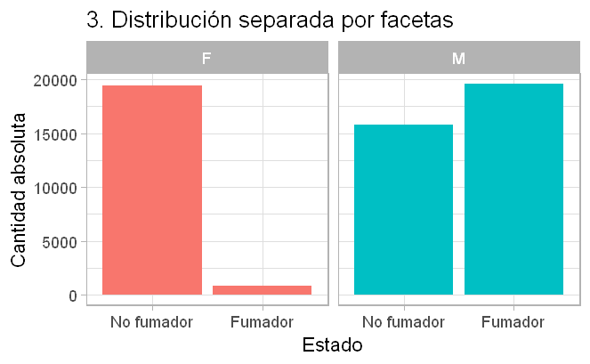

```r
gr3
```

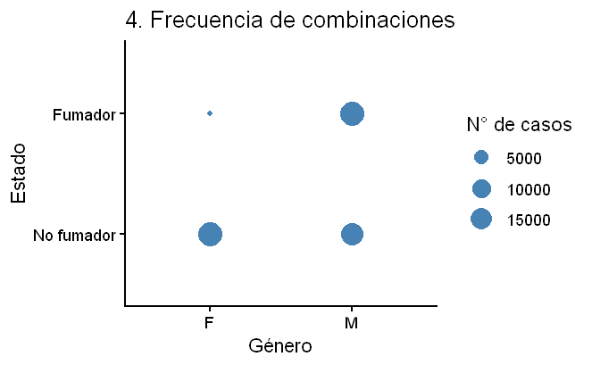

```r
gr4
```

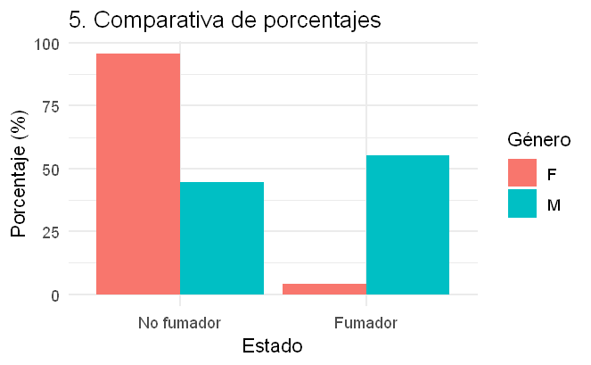

```r
gr5
```